# Convolutional Neural Networks

## Project: Write an Algorithm for a Dog Identification App

In this notebook, some template code has already been provided for you, and you will need to implement additional functionality to successfully complete this project. You will not need to modify the included code beyond what is requested. Sections that begin with **'(IMPLEMENTATION)'** in the header indicate that the following block of code will require additional functionality which you must provide. Instructions will be provided for each section, and the specifics of the implementation are marked in the code block with a 'TODO' statement. Please be sure to read the instructions carefully!

> **Note**: Once you have completed all of the code implementations, you need to finalize your work by exporting the Jupyter Notebook as an HTML document. Before exporting the notebook to html, all of the code cells need to have been run so that reviewers can see the final implementation and output. You can then export the notebook by using the menu above and navigating to **File -> Download as -> HTML (.html)**. Include the finished document along with this notebook as your submission.

In addition to implementing code, there will be questions that you must answer which relate to the project and your implementation. Each section where you will answer a question is preceded by a **'Question X'** header. Carefully read each question and provide thorough answers in the following text boxes that begin with **'Answer:'**. Your project submission will be evaluated based on your answers to each of the questions and the implementation you provide.

> **Note:** Code and Markdown cells can be executed using the **Shift + Enter** keyboard shortcut. Markdown cells can be edited by double-clicking the cell to enter edit mode.

The rubric contains *optional* "Stand Out Suggestions" for enhancing the project beyond the minimum requirements. If you decide to pursue the "Stand Out Suggestions", you should include the code in this Jupyter notebook.

### Why We're Here

In this notebook, you will make the first steps towards developing an algorithm that could be used as part of a mobile or web app. At the end of this project, your code will accept any user-supplied image as input. If a dog is detected in the image, it will provide an estimate of the dog's breed. If a human is detected, it will provide an estimate of the dog breed that is most resembling. The image below displays potential sample output of your finished project (... but we expect that each student's algorithm will behave differently!).

[figure not shown]

In this real-world setting, you will need to piece together a series of models to perform different tasks; for instance, the algorithm that detects humans in an image will be different from the CNN that infers dog breed. There are many points of possible failure, and no perfect algorithm exists. Your imperfect solution will nonetheless create a fun user experience!

### The Road Ahead

We break the notebook into separate steps. Feel free to use the links below to navigate the notebook.

- Step 0: Import Datasets
- Step 1: Detect Humans
- Step 2: Detect Dogs
- Step 3: Create a CNN to Classify Dog Breeds (from Scratch)
- Step 4: Create a CNN to Classify Dog Breeds (using Transfer Learning)
- Step 5: Write your Algorithm
- Step 6: Test Your Algorithm

## Step 0: Import Datasets

Make sure that you've downloaded the required human and dog datasets:

- Download the [dog dataset](https://s3-us-west-1.amazonaws.com/udacity-aind/dog-project/dogImages.zip). Unzip the folder and place it in this project's home directory, at the location `/dogImages`.
- Download the [human dataset](https://s3-us-west-1.amazonaws.com/udacity-aind/dog-project/lfw.zip). Unzip the folder and place it in the home directory, at location `/lfw`.

*Note: If you are using a Windows machine, you are encouraged to use [7zip](http://www.7-zip.org/) to extract the folder.*

In the code cell below, we save the file paths for both the human (LFW) dataset and dog dataset in the numpy arrays `human_files` and `dog_files`.

```python
import numpy as np
from glob import glob

# load filenames for human and dog images
human_files = np.array(glob("lfw/*/*"))
dog_files = np.array(glob("dogImages/*/*/*"))

# print number of images in each dataset
print('There are %d total human images.' % len(human_files))
print('There are %d total dog images.' % len(dog_files))
```

```
There are 13233 total human images.
There are 8351 total dog images.
```

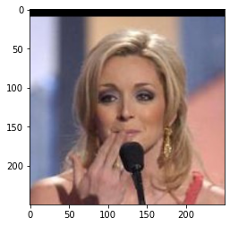

[figure not shown]

```python
#View the sample human photos.
import random
from PIL import Image
import cv2
import matplotlib.pyplot as plt
%matplotlib inline

for img in random.sample(list(human_files), 2):
#open and display input image
    image = Image.open(img) #img_path
    plt.imshow(image)
    plt.show()
```

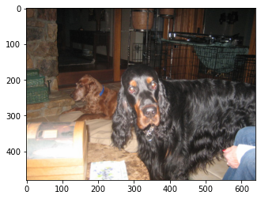

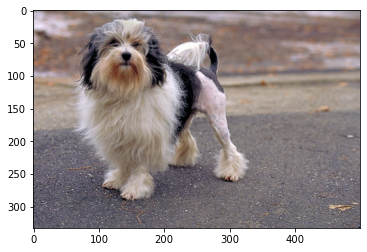

```python
#View the sample dog photos.
for img in random.sample(list(dog_files), 2):
#open and display input image
    image = Image.open(img) #img_path
    plt.imshow(image)
    plt.show()
```

```python
def filtered_images(image_path):
    mono_images=[]
    non_mono_images=[]
    for filename in image_path:
        try:
            img=Image.open(filename)
            #check pixel distribution
            v=img.histogram()
            h,w=img.size
            percentage_monochrome=max(v)/float(h*w)
            # filter bad and small images
            if percentage_monochrome>0.5 :#or h<300 or w<300:
                mono_images.append(filename)
            else:
                non_mono_images.append(filename)
        except:
            pass
    print("Number of monochrome images: {}\n".format(len(mono_images)))
    print("Number of non-monochrome images: {}\n".format(len(non_mono_images)))
    return mono_images, non_mono_images
```

```python
g,b=filtered_images(dog_files)
```

```
Number of monochrome images: 100

Number of non-monochrome images: 8251
```

# Create image frequency distribution for each dog class

```python
import os
from pandas import DataFrame
entries = os.listdir('dogImages/train')
df = DataFrame (entries,columns=['dogbreed'])
df['frequency']=0
df
```

|  | dogbreed | frequency |
| --- | --- | --- |
| 0 | 001.Affenpinscher | 0 |
| 1 | 002.Afghan_hound | 0 |
| 2 | 003.Airedale_terrier | 0 |
| 3 | 004.Akita | 0 |
| 4 | 005.Alaskan_malamute | 0 |
| ... | ... | ... |
| 128 | 129.Tibetan_mastiff | 0 |
| 129 | 130.Welsh_springer_spaniel | 0 |
| 130 | 131.Wirehaired_pointing_griffon | 0 |
| 131 | 132.Xoloitzcuintli | 0 |
| 132 | 133.Yorkshire_terrier | 0 |

133 rows × 2 columns

```python
humanlist=os.listdir('lfw')
dfhuman=DataFrame(humanlist,columns=['names'])
dfhuman['freq']=0
dfhuman
```

|  | names | freq |
| --- | --- | --- |
| 0 | .DS_Store | 0 |
| 1 | Aaron_Eckhart | 0 |
| 2 | Aaron_Guiel | 0 |
| 3 | Aaron_Patterson | 0 |
| 4 | Aaron_Peirsol | 0 |
| ... | ... | ... |
| 5745 | Zorica_Radovic | 0 |
| 5746 | Zulfiqar_Ahmed | 0 |
| 5747 | Zumrati_Juma | 0 |
| 5748 | Zurab_Tsereteli | 0 |
| 5749 | Zydrunas_Ilgauskas | 0 |

5750 rows × 2 columns

Test to assign class with 1 frequency.

Generate loop to find folders, following loop to find the subfolders.

```python
def images_perfolder(main_path):
    main_folders=glob(main_path)
    dist_dict={}
    dist_df=pd.DataFrame()
    for fold in main_folders:
        folder_nm=os.path.basename(os.path.normpath(fold))
        print("# of images in",fold,":",len(glob(os.path.join(fold,"*","*"))))
        sub_folders=glob(os.path.join(fold,"*"))
        for breed_fold in sub_folders:
            breed_name=os.path.basename(os.path.normpath(breed_fold))
            dist_dict[breed_name]=len(glob(os.path.join(breed_fold,'*')))

        fold_df=pd.DataFrame.from_dict(dist_dict,orient='index').reset_index()
        fold_df['folder']=folder_nm
        dist_df=pd.concat([dist_df,fold_df],axis=0,ignore_index=True, sort=False)
    dist_df.rename(columns={0:'num_images','index':'category'},inplace=True)
    print(dist_df.groupby('folder')['num_images'].sum())
    return dist_df
```

```python
dog_dist_df=images_perfolder('dogImages/*/')
dog_dist_df
```

```
# of images in dogImages\test\ : 836
# of images in dogImages\train\ : 6680
# of images in dogImages\valid\ : 835
folder
test      836
train    6680
valid     835
Name: num_images, dtype: int64
```

|  | category | num_images | folder |
| --- | --- | --- | --- |
| 0 | 001.Affenpinscher | 8 | test |
| 1 | 002.Afghan_hound | 8 | test |
| 2 | 003.Airedale_terrier | 6 | test |
| 3 | 004.Akita | 8 | test |
| 4 | 005.Alaskan_malamute | 10 | test |
| ... | ... | ... | ... |
| 394 | 129.Tibetan_mastiff | 6 | valid |
| 395 | 130.Welsh_springer_spaniel | 6 | valid |
| 396 | 131.Wirehaired_pointing_griffon | 4 | valid |
| 397 | 132.Xoloitzcuintli | 4 | valid |
| 398 | 133.Yorkshire_terrier | 4 | valid |

399 rows × 3 columns

```
category
001.Affenpinscher                  80
002.Afghan_hound                   73
003.Airedale_terrier               65
004.Akita                          79
005.Alaskan_malamute               96
                                   ..
129.Tibetan_mastiff                60
130.Welsh_springer_spaniel         55
131.Wirehaired_pointing_griffon    37
132.Xoloitzcuintli                 33
133.Yorkshire_terrier              38
Name: num_images, Length: 133, dtype: int64
```

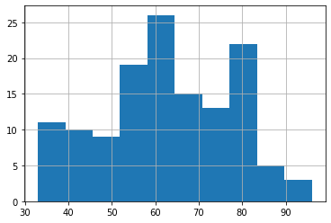

```python
totalbybreed=dog_dist_df.groupby("category").num_images.sum()
print(totalbybreed)
totalbybreed.hist()
```

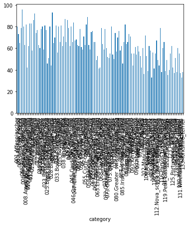

```python
totalbybreed.plot(kind="bar")
```

```python
totalbybreed.describe()
```

```
count    133.000000
mean      62.789474
std       14.852330
min       33.000000
25%       53.000000
50%       62.000000
75%       76.000000
max       96.000000
Name: num_images, dtype: float64
```

```python
def images_perfolderhuman(main_path):
    main_folders=glob(main_path)
    dist_dict={}
    dist_df=pd.DataFrame()
    for fold in main_folders:
        folder_nm=os.path.basename(os.path.normpath(fold))
  #      print("# of images in",fold,":",len(glob(os.path.join(fold,"*"))))
        dist_dict[folder_nm]=len(glob(os.path.join(fold,'*')))

        fold_df=pd.DataFrame.from_dict(dist_dict,orient='index').reset_index()
        fold_df['folder']=folder_nm
        dist_df=pd.concat([dist_df,fold_df],axis=0,ignore_index=True, sort=False)
 #   dist_df.rename(columns={0:'num_images','index':'category'},inplace=True)
#     print(dist_df.groupby('folder')['num_images'].sum())
    return dist_df
```

```python
main_folders=glob('lfw/*/')
dist_dict={}
dist_df=pd.DataFrame()
for fold in main_folders:
    folder_nm=os.path.basename(os.path.normpath(fold))
    print("# of images in",fold,":",len(glob(os.path.join(fold,"*"))))
    dist_dict[folder_nm]=len(glob(os.path.join(fold,'*')))

    fold_df=pd.DataFrame.from_dict(dist_dict,orient='index').reset_index()
    fold_df['folder']=folder_nm
    dist_df=pd.concat([dist_df,fold_df],axis=0,ignore_index=True, sort=False)
dist_df.rename(columns={0:'num_images','index':'category'},inplace=True)
print(dist_df.groupby('folder')['num_images'].sum())
```

[output not shown]

[output cut: 5707 more lines]

[output not shown]

```python
human_dist_df=images_perfolderhuman('lfw/*/')
human_dist_df
```

[output not shown]

[output cut: 29 more lines]

[output not shown]

```python
totalbyhuman=human_dist_df.groupby("folder").num_images.sum()
print(totalbyhuman)
totalbyhuman.hist()
```

[output not shown]

## Step 1: Detect Humans

In this section, we use OpenCV's implementation of [Haar feature-based cascade classifiers](http://docs.opencv.org/trunk/d7/d8b/tutorial_py_face_detection.html) to detect human faces in images.

OpenCV provides many pre-trained face detectors, stored as XML files on [github](https://github.com/opencv/opencv/tree/master/data/haarcascades). We have downloaded one of these detectors and stored it in the `haarcascades` directory. In the next code cell, we demonstrate how to use this detector to find human faces in a sample image.

```
Number of faces detected: 1
```

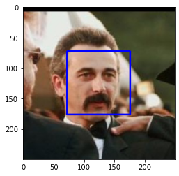

```python
# extract pre-trained face detector
face_cascade = cv2.CascadeClassifier('haarcascades/haarcascade_frontalface_alt.xml')

# load color (BGR) image
img = cv2.imread(human_files[10])
# convert BGR image to grayscale
gray = cv2.cvtColor(img, cv2.COLOR_BGR2GRAY)

# find faces in image
faces = face_cascade.detectMultiScale(gray)

# print number of faces detected in the image
print('Number of faces detected:', len(faces))

# get bounding box for each detected face
for (x,y,w,h) in faces:
    # add bounding box to color image
    cv2.rectangle(img,(x,y),(x+w,y+h),(255,0,0),2)

# convert BGR image to RGB for plotting
cv_rgb = cv2.cvtColor(img, cv2.COLOR_BGR2RGB)

# display the image, along with bounding box
plt.imshow(cv_rgb)
plt.show()
```

Before using any of the face detectors, it is standard procedure to convert the images to grayscale. The `detectMultiScale` function executes the classifier stored in `face_cascade` and takes the grayscale image as a parameter.

In the above code, `faces` is a numpy array of detected faces, where each row corresponds to a detected face. Each detected face is a 1D array with four entries that specifies the bounding box of the detected face. The first two entries in the array (extracted in the above code as `x` and `y`) specify the horizontal and vertical positions of the top left corner of the bounding box. The last two entries in the array (extracted here as `w` and `h`) specify the width and height of the box.

### Write a Human Face Detector

We can use this procedure to write a function that returns `True` if a human face is detected in an image and `False` otherwise. This function, aptly named `face_detector`, takes a string-valued file path to an image as input and appears in the code block below.

```python
# returns "True" if face is detected in image stored at img_path
def face_detector(img_path):
    img = cv2.imread(img_path)
    gray = cv2.cvtColor(img, cv2.COLOR_BGR2GRAY)
    faces = face_cascade.detectMultiScale(gray)
    return len(faces) > 0
```

### (IMPLEMENTATION) Assess the Human Face Detector

**Question 1:** Use the code cell below to test the performance of the `face_detector` function.

- What percentage of the first 100 images in `human_files` have a detected human face?
- What percentage of the first 100 images in `dog_files` have a detected human face?

Ideally, we would like 100% of human images with a detected face and 0% of dog images with a detected face. You will see that our algorithm falls short of this goal, but still gives acceptable performance. We extract the file paths for the first 100 images from each of the datasets and store them in the numpy arrays `human_files_short` and `dog_files_short`.

**Answer:** (You can print out your results and/or write your percentages in this cell)

```python
from tqdm import tqdm
human_files_short = human_files[:100]
dog_files_short = dog_files[:100]
#-#-# Do NOT modify the code above this line. #-#-#

## TODO: Test the performance of the face_detector algorithm
## on the images in human_files_short and dog_files_short.
# run the function face_detector to check number of True values.

#define first row
k=0
number_human_face=0
number_dog_face=0
#create loop to run all rows, since human and dog are using 100 images
for k in tqdm(range(len(human_files_short))):
    if face_detector(human_files_short[k]) == True:
        number_human_face+=1
    if face_detector(dog_files_short[k]) == True:
        number_dog_face+=1
    k+=1
percent_human=(number_human_face/len(human_files_short))*100
print('human faces ',percent_human, "%")
percent_dog=(number_dog_face/len(dog_files_short))*100
print('dog faces ',percent_dog, "%")
```

```
human faces  96.0 %
dog faces  18.0 %
```

We suggest the face detector from OpenCV as a potential way to detect human images in your algorithm, but you are free to explore other approaches, especially approaches that make use of deep learning :). Please use the code cell below to design and test your own face detection algorithm. If you decide to pursue this *optional* task, report performance on `human_files_short` and `dog_files_short`.

```python
### (Optional)
### TODO: Test performance of another face detection algorithm.
### Feel free to use as many code cells as needed.

# extract pre-trained face detector
face_cascade2 = cv2.CascadeClassifier('lbpcascades/lbpcascade_frontalface.xml')
```

```python
# returns "True" if face is detected in image stored at img_path
def face_detector2(img_path):
    img = cv2.imread(img_path)
    gray = cv2.cvtColor(img, cv2.COLOR_BGR2GRAY)
    faces2 = face_cascade2.detectMultiScale(gray)
    return len(faces2) > 0
```

```python
#define first row
k=0
number_human_face=0
number_dog_face=0
#create loop to run all rows, since human and dog are using 100 images
for k in tqdm(range(len(human_files_short))):
    if face_detector2(human_files_short[k]):
        number_human_face+=1
    if face_detector2(dog_files_short[k]):
        number_dog_face+=1
    k+=1
percent_human=(number_human_face/len(human_files_short))*100
print('human faces ',percent_human, "%")
percent_dog=(number_dog_face/len(dog_files_short))*100
print('dog faces ',percent_dog, "%")
```

```
human faces  92.0 %
dog faces  31.0 %
```

## Step 2: Detect Dogs

In this section, we use a [pre-trained model](http://pytorch.org/docs/master/torchvision/models.html) to detect dogs in images.

### Obtain Pre-trained VGG-16 Model

The code cell below downloads the VGG-16 model, along with weights that have been trained on [ImageNet](http://www.image-net.org/), a very large, very popular dataset used for image classification and other vision tasks. ImageNet contains over 10 million URLs, each linking to an image containing an object from one of [1000 categories](https://gist.github.com/yrevar/942d3a0ac09ec9e5eb3a).

```python
import torch
import torchvision.models as models

# define VGG16 model
VGG16 = models.vgg16(pretrained=True)

# check if CUDA is available
use_cuda = torch.cuda.is_available()

# move model to GPU if CUDA is available
if use_cuda:
    VGG16 = VGG16.cuda()
```

```python
VGG16
```

```
VGG(
  (features): Sequential(
    (0): Conv2d(3, 64, kernel_size=(3, 3), stride=(1, 1), padding=(1, 1))
    (1): ReLU(inplace=True)
    (2): Conv2d(64, 64, kernel_size=(3, 3), stride=(1, 1), padding=(1, 1))
    (3): ReLU(inplace=True)
    (4): MaxPool2d(kernel_size=2, stride=2, padding=0, dilation=1, ceil_mode=False)
    (5): Conv2d(64, 128, kernel_size=(3, 3), stride=(1, 1), padding=(1, 1))
    (6): ReLU(inplace=True)
    (7): Conv2d(128, 128, kernel_size=(3, 3), stride=(1, 1), padding=(1, 1))
    (8): ReLU(inplace=True)
    (9): MaxPool2d(kernel_size=2, stride=2, padding=0, dilation=1, ceil_mode=False)
    (10): Conv2d(128, 256, kernel_size=(3, 3), stride=(1, 1), padding=(1, 1))
    (11): ReLU(inplace=True)
    (12): Conv2d(256, 256, kernel_size=(3, 3), stride=(1, 1), padding=(1, 1))
    (13): ReLU(inplace=True)
    (14): Conv2d(256, 256, kernel_size=(3, 3), stride=(1, 1), padding=(1, 1))
    (15): ReLU(inplace=True)
    (16): MaxPool2d(kernel_size=2, stride=2, padding=0, dilation=1, ceil_mode=False)
    (17): Conv2d(256, 512, kernel_size=(3, 3), stride=(1, 1), padding=(1, 1))
    (18): ReLU(inplace=True)
    (19): Conv2d(512, 512, kernel_size=(3, 3), stride=(1, 1), padding=(1, 1))
    (20): ReLU(inplace=True)
    (21): Conv2d(512, 512, kernel_size=(3, 3), stride=(1, 1), padding=(1, 1))
    (22): ReLU(inplace=True)
    (23): MaxPool2d(kernel_size=2, stride=2, padding=0, dilation=1, ceil_mode=False)
    (24): Conv2d(512, 512, kernel_size=(3, 3), stride=(1, 1), padding=(1, 1))
    (25): ReLU(inplace=True)
    (26): Conv2d(512, 512, kernel_size=(3, 3), stride=(1, 1), padding=(1, 1))
    (27): ReLU(inplace=True)
    (28): Conv2d(512, 512, kernel_size=(3, 3), stride=(1, 1), padding=(1, 1))
    (29): ReLU(inplace=True)
    (30): MaxPool2d(kernel_size=2, stride=2, padding=0, dilation=1, ceil_mode=False)
  )
  (avgpool): AdaptiveAvgPool2d(output_size=(7, 7))
  (classifier): Sequential(
    (0): Linear(in_features=25088, out_features=4096, bias=True)
    (1): ReLU(inplace=True)
    (2): Dropout(p=0.5, inplace=False)
    (3): Linear(in_features=4096, out_features=4096, bias=True)
    (4): ReLU(inplace=True)
    (5): Dropout(p=0.5, inplace=False)
    (6): Linear(in_features=4096, out_features=1000, bias=True)
  )
)
```

Given an image, this pre-trained VGG-16 model returns a prediction (derived from the 1000 possible categories in ImageNet) for the object that is contained in the image.

### (IMPLEMENTATION) Making Predictions with a Pre-trained Model

In the next code cell, you will write a function that accepts a path to an image (such as `'dogImages/train/001.Affenpinscher/Affenpinscher_00001.jpg'`) as input and returns the index corresponding to the ImageNet class that is predicted by the pre-trained VGG-16 model. The output should always be an integer between 0 and 999, inclusive.

Before writing the function, make sure that you take the time to learn how to appropriately pre-process tensors for pre-trained models in the [PyTorch documentation](http://pytorch.org/docs/stable/torchvision/models.html).

```python
import io
from PIL import Image
import torchvision.transforms as transforms

# Set PIL to be tolerant of image files that are truncated.
from PIL import ImageFile
ImageFile.LOAD_TRUNCATED_IMAGES = True

import numpy as np

train_on_gpu = torch.cuda.is_available()
    #Check if available to train on gpu
if not train_on_gpu:
    print('CUDA is not available.  Training on CPU ...')
else:
    print('CUDA is available!  Training on GPU ...')


def VGG16_predict(img_path):
    '''
    Use pre-trained VGG-16 model to obtain index corresponding to
    predicted ImageNet class for image at specified path
    Args:
        img_path: path to an image
    Returns:
        Index corresponding to VGG-16 model's prediction
    '''
    #open image file
    input_image = Image.open(img_path)
    #preprocess function defined which transform the image so that images are converted to tensors,
    #all consistent size and normalised accordingly
    preprocess = transforms.Compose([transforms.Resize(256),transforms.CenterCrop(224),transforms.ToTensor(),
                                     transforms.Normalize(mean=[0.485, 0.456, 0.406], std=[0.229, 0.224, 0.225])])

    input_tensor = preprocess(input_image) #create input tensor by feeding input image with the preprocess function.
    input_batch = input_tensor.unsqueeze(0) # create a mini-batch as expected by the model

    with torch.no_grad(): #no back propogation altering the gradients. Keeping the model attributes the same.
        output = VGG16(input_batch) #Tensor of shape 1000, with confidence scores over Imagenet's 1000 classes
    # print(output)
    # The output has unnormalized scores. To get probabilities, you can run a softmax on it.
    # print(torch.nn.functional.softmax(output[0], dim=0))

    #extract the index with the maximum value in the second dimension which has 0:999 classes of dogs
    xx,predicted = output.max(dim=1)    #xx is the value, predicted is the class index

    #print('Pre-trained model predicts an index of', predicted.item())
    return predicted.item()
```

```
CUDA is not available.  Training on CPU ...
```

### (IMPLEMENTATION) Write a Dog Detector

While looking at the [dictionary](https://gist.github.com/yrevar/942d3a0ac09ec9e5eb3a), you will notice that the categories corresponding to dogs appear in an uninterrupted sequence and correspond to dictionary keys 151-268, inclusive, to include all categories from `'Chihuahua'` to `'Mexican hairless'`. Thus, in order to check to see if an image is predicted to contain a dog by the pre-trained VGG-16 model, we need only check if the pre-trained model predicts an index between 151 and 268 (inclusive).

Use these ideas to complete the `dog_detector` function below, which returns `True` if a dog is detected in an image (and `False` if not).

```python
### returns "True" if a dog is detected in the image stored at img_path
def dog_detector(img_path):
    ## TODO: Complete the function.
    # check prediction of the image
    index_predict=VGG16_predict(img_path)

#     #check if output index is between 151 and 268. If yes, True, False for No.

    if index_predict >151 and index_predict<268:
        return True
    else:
        return False
```

```python
#just to test it out
dog_detector(human_files[0])
```

```
False
```

### (IMPLEMENTATION) Assess the Dog Detector

**Question 2:** Use the code cell below to test the performance of your `dog_detector` function.

- What percentage of the images in `human_files_short` have a detected dog?
- What percentage of the images in `dog_files_short` have a detected dog?

**Answer:**

```python
### TODO: Test the performance of the dog_detector function
### on the images in human_files_short and dog_files_short.
nbr_human=0
nbr_dog=0
i=0
for i in tqdm(range(len(human_files_short))):
    if dog_detector(human_files_short[i]):
        nbr_human+=1
    if dog_detector(dog_files_short[i]):
        nbr_dog+=1
    i+=1

percent_human=(nbr_human/len(human_files_short))*100
print('detect a dog in human_files',percent_human, "%")
percent_dog=(nbr_dog/len(dog_files_short))*100
print('detect a dog in dog_files',percent_dog, "%")
```

```
detect a dog in human_files 0.0 %
detect a dog in dog_files 95.0 %
```

We suggest VGG-16 as a potential network to detect dog images in your algorithm, but you are free to explore other pre-trained networks (such as [Inception-v3](http://pytorch.org/docs/master/torchvision/models.html#inception-v3), [ResNet-50](http://pytorch.org/docs/master/torchvision/models.html#id3), etc). Please use the code cell below to test other pre-trained PyTorch models. If you decide to pursue this *optional* task, report performance on `human_files_short` and `dog_files_short`.

```python
### (Optional)
### TODO: Report the performance of another pre-trained network.
### test the Inceptionv3 model

import torch
import torchvision.models as models

# define inception_v3 model
inceptionv3 = models.inception_v3(pretrained=True)
inceptionv3.eval()
# check if CUDA is available
#use_cuda = torch.cuda.is_available()

# move model to GPU if CUDA is available
#if use_cuda:
#    inceptionv3 = inceptionv3.cuda()
```

[output not shown]

[output cut: 357 more lines]

[output not shown]

```python
train_on_gpu = torch.cuda.is_available()
    #Check if available to train on gpu
if not train_on_gpu:
    print('CUDA is not available.  Training on CPU ...')
else:
    print('CUDA is available!  Training on GPU ...')


def inceptionv3_predict(img_path):

    #open image file
    input_image = Image.open(img_path)
    #preprocess function defined which transform the image so that images are converted to tensors,
    #all consistent size and normalised accordingly
    preprocess = transforms.Compose([transforms.Resize(299),transforms.CenterCrop(299),transforms.ToTensor(),
                                     transforms.Normalize(mean=[0.485, 0.456, 0.406], std=[0.229, 0.224, 0.225])])

    input_tensor = preprocess(input_image)
    input_batch = input_tensor.unsqueeze(0) # create a mini-batch as expected by the model

    with torch.no_grad(): #no back propogation altering the gradients. Keeping the model attributes the same.
        output = inceptionv3(input_batch)

    #extract the index with the maximum value in the second dimension which has 0:999 classes of dogs
    xx,predicted = output.max(dim=1)

    return predicted.item()
```

```
CUDA is not available.  Training on CPU ...
```

```python
### returns "True" if a dog is detected in the image stored at img_path
def dog_detector2(img_path):
    ## TODO: Complete the function.
    # check prediction of the image
    index_predict=inceptionv3_predict(img_path)

#     #check if output index is between 151 and 268. If yes, True, False for No.

    if index_predict >151 and index_predict<268:
        return True
    else:
        return False
```

```python
x=Image.open(dog_files_short[50])
preprocess = transforms.Compose([transforms.Resize(299),transforms.CenterCrop(299),transforms.ToTensor(),
                                     transforms.Normalize(mean=[0.485, 0.456, 0.406], std=[0.229, 0.224, 0.225])])
input_tensor=preprocess(x)
input_batch = input_tensor.unsqueeze(0)
with torch.no_grad(): #no back propogation altering the gradients. Keeping the model attributes the same.
    output = inceptionv3(input_batch)
```

```python
output
```

[output not shown]

[output cut: 145 more lines]

[output not shown]

```python
dog_detector2(human_files_short[50])
```

```
False
```

```python
### TODO: Test the performance of the dog_detector function
### on the images in human_files_short and dog_files_short.
nbr_human=0
nbr_dog=0
i=0
for i in tqdm(range(len(human_files_short))):
    if dog_detector2(human_files_short[i]):
        nbr_human+=1
    if dog_detector2(dog_files_short[i]):
        nbr_dog+=1
    i+=1

percent_human=(nbr_human/len(human_files_short))*100
print('detect a dog in human_files',percent_human, "%")
percent_dog=(nbr_dog/len(dog_files_short))*100
print('detect a dog in dog_files',percent_dog, "%")
```

```
detect a dog in human_files 0.0 %
detect a dog in dog_files 96.0 %
```

## Step 3: Create a CNN to Classify Dog Breeds (from Scratch)

Now that we have functions for detecting humans and dogs in images, we need a way to predict breed from images. In this step, you will create a CNN that classifies dog breeds. You must create your CNN *from scratch* (so, you can't use transfer learning *yet*!), and you must attain a test accuracy of at least 10%. In Step 4 of this notebook, you will have the opportunity to use transfer learning to create a CNN that attains greatly improved accuracy.

We mention that the task of assigning breed to dogs from images is considered exceptionally challenging. To see why, consider that *even a human* would have trouble distinguishing between a Brittany and a Welsh Springer Spaniel.

| Brittany | Welsh Springer Spaniel |
| --- | --- |

It is not difficult to find other dog breed pairs with minimal inter-class variation (for instance, Curly-Coated Retrievers and American Water Spaniels).

| Curly-Coated Retriever | American Water Spaniel |
| --- | --- |

Likewise, recall that labradors come in yellow, chocolate, and black. Your vision-based algorithm will have to conquer this high intra-class variation to determine how to classify all of these different shades as the same breed.

| Yellow Labrador | Chocolate Labrador | Black Labrador |
| --- | --- | --- |

We also mention that random chance presents an exceptionally low bar: setting aside the fact that the classes are slightly imabalanced, a random guess will provide a correct answer roughly 1 in 133 times, which corresponds to an accuracy of less than 1%.

Remember that the practice is far ahead of the theory in deep learning. Experiment with many different architectures, and trust your intuition. And, of course, have fun!

### (IMPLEMENTATION) Specify Data Loaders for the Dog Dataset

Use the code cell below to write three separate [data loaders](http://pytorch.org/docs/stable/data.html#torch.utils.data.DataLoader) for the training, validation, and test datasets of dog images (located at `dogImages/train`, `dogImages/valid`, and `dogImages/test`, respectively). You may find [this documentation on custom datasets](http://pytorch.org/docs/stable/torchvision/datasets.html) to be a useful resource. If you are interested in augmenting your training and/or validation data, check out the wide variety of [transforms](http://pytorch.org/docs/stable/torchvision/transforms.html?highlight=transform)!

```python
import os
from random import shuffle
from __future__ import print_function, division
import torch
from torch.utils.data import Dataset, DataLoader
from torchvision import datasets
from torchvision import transforms, utils

### TODO: Write data loaders for training, validation, and test sets
# define training, test and validation data directories, if on udacity: use /data/....
train_dir = 'dogImages/train'
valid_dir = 'dogImages/valid'
test_dir = 'dogImages/test'

standard_normalization = transforms.Normalize(mean=[0.485, 0.456, 0.406],
                                              std=[0.229, 0.224, 0.225])
#define transform criterias
train_transforms = transforms.Compose([transforms.Resize(size=256),
                                       transforms.RandomHorizontalFlip(),
                                       transforms.RandomRotation(10),
                                       transforms.CenterCrop(224),
                                       transforms.ToTensor(),
                                       standard_normalization])
validTest_transforms = transforms.Compose([transforms.Resize(size=256),
                                           transforms.CenterCrop(224),
                                           transforms.ToTensor(),
                                           standard_normalization])

#create the transformed images into tensors datasets
datatrain = datasets.ImageFolder(train_dir, train_transforms)
datavalid = datasets.ImageFolder(valid_dir, validTest_transforms)
datatest = datasets.ImageFolder(test_dir, validTest_transforms)

#prepare data loaders for each dataset which will be used to feed into the model for batch training, test and validation.
#training loader
train_loader = torch.utils.data.DataLoader(datatrain,batch_size=32,shuffle=True,num_workers=0)
#test loader
valid_loader = torch.utils.data.DataLoader(datavalid,batch_size=32,shuffle=True,num_workers=0)
# test loader
test_loader = torch.utils.data.DataLoader(datatest,batch_size=32,shuffle=True,num_workers=0)
```

**Question 3:** Describe your chosen procedure for preprocessing the data.

- How does your code resize the images (by cropping, stretching, etc)? What size did you pick for the input tensor, and why?
- Did you decide to augment the dataset? If so, how (through translations, flips, rotations, etc)? If not, why not?

**Answer**:The images are resized to 256 pixels and centre cropped 224 pixels. If I crop before resize, I might not caputre all the key feature, thus it is crucial to resize and crop after.

Looking from the sample images on dogimages. The photo of the dogs have their heads being captured in the image and sometimes their body or head is nor orientated right up thus I used a randomrotation. Sometimes the body and head is oiriented from left to right instead of right to left, thus a horizontal random flip is used.

Image augmentation will create randomness to the dataset created, prevents overfitting, thus giving better overall performance for prediction. Since validation and test data will be used for validation and test check, no randomhorizontal flip or rotation was used.